# Big Data Science - Assignment 1

EEG Analysis

Arnau Casanova & Alex Flores

2018-02-05

# Problem Definition

## Case: Does the brain works in the same way in front of a visual stimulus with alcoholic and non-alcoholic persons?

With this experiment we will see if there is a significative diference between alcoholic and non-alcoholic users that are connected to 64 sensors within three type of visual experiments.

[output not shown]

> The main **goal** is to check wheter a user is alcoholic or non-alcoholic through their signal pattern

# Step 3 - Data Acquisition

## How to load the data?

To load our data we will use the manual download method of the full egg tar, we just need to unzip the full tar and then unzip the selected users to deal with, also we need to set the directories of the respective users readings, the process file function will do all the job to manage the data in the way we want.

```r
#Process file function
getwd()
user <- ""
state <- ""
trial <- ""
expType <- ""
sensors <- list()
userValues <- list()
#Step 4:
process_file <- function(filename){
  conn <<- file(filename,open="r")
  linn <-readLines(conn)

  userAux <- str_sub(linn[1],3,13)
  stateAux <- str_sub(linn[1],6,6)
  expTypeA <- str_split_fixed(linn[4], ",", n=2)
  trialA <- expTypeA[2]
  expTypeA <- expTypeA[1]
  expTypeA <- str_split_fixed(expTypeA, "#", n=2)
  expTypeA <- expTypeA[2]
  expTypeA <- str_trim(expTypeA, side = c("left"))

  user <<- userAux
  print(user)

  state <<- stateAux
  print(state)

  expType <<- expTypeA
  print(expType)

  trial <<- trialA
  print(trial)
  sensorsIndex <- 1;
  valuesIndex <- 1;


  for (i in 5:length(linn)){
    firstChar <- str_split_fixed(linn[i], " ", n=4)
    firstChar <- firstChar[1]
    if(firstChar == "#"){
      testLinia <- linn[i]
      testLinia <- str_split_fixed(testLinia, " ", n=4)
      testLinia <- testLinia[2]
      sensors[sensorsIndex] <<- testLinia
      sensorsIndex <- sensorsIndex + 1
    }
    else{
      linia <- linn[i]
      value <- str_split_fixed(linia, " ", n=4)
      value <- value[4]
      userValues[valuesIndex] <<- value
      valuesIndex <- valuesIndex + 1
    }
  }
}
```

## How to save the data?

After unziping the full data set and selecting specific users and processing those files, three txt files will be created, always specifing the path, this is because the structure of the taken data is not the way we want, the first one is a file with all the data of the experiment and the others are the alcholic and non-alcoholic data sets, this file process may take many minutes since the quantity of data we are managing is really big.

## In which format the data needs to be keept?

As every file has 16.000 rows we need to think a method to keep the data in a clear format, observing that the sample is going always from 1 to 256, in order to avoid that noisy repetition we will structure each file with 256 rows, and the columns of the result will be: the user id, the state of the user(alcoholic/non-alcoholic), the experiment type, the sample, the trial and all the 64 sensors.

## How many data we want to deal with?

The objective of the assignment is to analyze differences between alcoholic and non-alcoholic, we could take the full data set but it would be a lot of data, in our case we will analyze two random users (alcoholic and non-alcholic) and we will compare the readings of them in order to extract some conclusions.

The following code will do the construction of the three files, using each iteration the function defined below:

```r
sensorsRow <- list()
userInfo <- list()
userInfo[1] <- "USER"
userInfo[2] <- "STATE"
userInfo[3] <- "EXP_TYPE"
userInfo[4] <- "SAMPLE"
userInfo[5] <- "TRIAL"
for(q in 1: 2){
  ##fileList = EEG files path
  ##connFile = connection to specific output file(alcoholic/non-alcoholic)
  ##connFileAll = connection to general output file

  if (q==1) {
    setwd("C:/Users/Arnau/Documents/BigDataScience/assignment1/co2a00004447")
    fileList <- list.files("C:/Users/Arnau/Documents/BigDataScience/assignment1/co2a00004447")
    connFile <- file("C:/Users/Arnau/Documents/BigDataScience/assignment1/alcoholicTable.txt", 'a')
    connFileAll <- file("C:/Users/Arnau/Documents/BigDataScience/assignment1/bigTable.txt", 'a')
    }
  else{
    setwd("C:/Users/Arnau/Documents/BigDataScience/assignment1/co2c0000337")
    fileList <- list.files("C:/Users/Arnau/Documents/BigDataScience/assignment1/co2c0000337")
    connFile <- file("C:/Users/Arnau/Documents/BigDataScience/assignment1/userTable.txt", 'a')
    connFileAll <- file("C:/Users/Arnau/Documents/BigDataScience/assignment1/bigTable.txt", 'a')
    }


    for (x in 1: length(fileList)){

      fileList[x]
      process_file(fileList[x])

      if(state == "a"){
        state <- "1"
      }else{
        state <- "0"
       }

      if (x == 1){
        for (i in 1: length(sensors)){
          sensors[i] <- toString(sensors[i])
        }
        header <- c(userInfo, sensors)
        header <- paste(unlist(header), collapse= " ")
        write(header, connFile, sep = " ")
        write(header, connFileAll, sep = " ")
      }
      for(i in 1: 256){
        indexAux <- 0
        for(j in 6: 69){
          sensorsRow[1] <- user
          sensorsRow[2] <- state
          expType <- str_replace_all(expType, " ", "")
          sensorsRow[3] <- expType
          sensorsRow[4] <- toString(i)
          trial <- str_replace_all(trial, " ", "")
          sensorsRow[5] <- trial
          sensorsRow[j] <- toString(userValues[i+indexAux])
          indexAux <- indexAux + 256
        }
      insertRow <- paste(unlist(sensorsRow), collapse=" ")
      write(insertRow, connFile, sep = " ")
      write(insertRow, connFileAll, sep = " ")
      }
    }
  close(connFileAll)
  close(connFile)
}
fileGeneral <- file("C:/Users/Arnau/Documents/BigDataScience/assignment1/bigTable.txt")
fileA <- file("C:/Users/Arnau/Documents/BigDataScience/assignment1/alcoholicTable.txt")
fileC <- file("C:/Users/Arnau/Documents/BigDataScience/assignment1/userTable.txt")
dfAlc <- read.table(fileA, header = TRUE, sep = " ")
dfCon <- read.table(fileC, header = TRUE, sep = " ")
df <- read.table(fileGeneral, header = TRUE, sep = " ")
```

After cleaning the dataset and keeping it in a tidy format, we can show the summary of the entire set of trials for each user:

```r
##120 trial control user summary
summary(dfCon)
```

```
          USER           STATE        EXP_TYPE         SAMPLE            TRIAL
 co2c0000337:19968   Min.   :0   S1obj    :10240   Min.   :  1.00   trial0  :  256
                     1st Qu.:0   S2match  : 5888   1st Qu.: 64.75   trial101:  256
                     Median :0   S2nomatch: 3840   Median :128.50   trial102:  256
                     Mean   :0                     Mean   :128.50   trial103:  256
                     3rd Qu.:0                     3rd Qu.:192.25   trial104:  256
                     Max.   :0                     Max.   :256.00   trial105:  256
                                                                    (Other) :18432
      FP1               FP2                F7                F8               AF1
 Min.   :-36.346   Min.   :-38.055   Min.   :-41.911   Min.   :-45.013   Min.   :-29.948
 1st Qu.: -9.410   1st Qu.: -9.359   1st Qu.:-10.630   1st Qu.: -9.247   1st Qu.: -8.586
 Median : -2.828   Median : -2.492   Median : -3.815   Median : -1.994   Median : -3.194
 Mean   : -2.205   Mean   : -1.494   Mean   : -3.718   Mean   : -1.574   Mean   : -2.930
 3rd Qu.:  3.204   3rd Qu.:  4.181   3rd Qu.:  2.830   3rd Qu.:  5.585   3rd Qu.:  1.933
 Max.   :156.728   Max.   :180.796   Max.   : 62.805   Max.   : 79.844   Max.   : 94.198

      AF2                FZ                F4                F3               FC6
 Min.   :-31.525   Min.   :-24.689   Min.   :-27.761   Min.   :-34.200   Min.   :-36.601
 1st Qu.: -8.352   1st Qu.: -7.406   1st Qu.: -7.334   1st Qu.: -7.751   1st Qu.: -8.936
 Median : -2.808   Median : -3.143   Median : -2.614   Median : -2.899   Median : -2.309
 Mean   : -2.447   Mean   : -3.093   Mean   : -2.433   Mean   : -2.868   Mean   : -1.889
 3rd Qu.:  2.370   3rd Qu.:  0.865   3rd Qu.:  2.116   3rd Qu.:  1.780   3rd Qu.:  4.720
 Max.   :101.410   Max.   : 53.955   Max.   : 60.038   Max.   : 52.094   Max.   : 47.709

      FC5               FC2               FC1                T8                T7
 Min.   :-24.221   Min.   :-17.537   Min.   :-19.348   Min.   :-38.127   Min.   :-32.318
 1st Qu.: -7.029   1st Qu.: -4.751   1st Qu.: -4.801   1st Qu.: -9.389   1st Qu.: -8.301
 Median : -2.635   Median : -1.912   Median : -2.024   Median : -2.675   Median : -2.777
 Mean   : -2.558   Mean   : -1.915   Mean   : -1.972   Mean   : -2.536   Mean   : -2.759
 3rd Qu.:  1.750   3rd Qu.:  0.885   3rd Qu.:  0.854   3rd Qu.:  3.937   3rd Qu.:  2.614
 Max.   : 22.532   Max.   : 25.503   Max.   : 24.841   Max.   : 37.872   Max.   : 28.137

       CZ                C3                C4               CP5               CP6
 Min.   :-94.655   Min.   :-19.969   Min.   :-33.213   Min.   :-28.910   Min.   :-33.020
 1st Qu.:-14.364   1st Qu.: -3.947   1st Qu.: -4.862   1st Qu.: -5.707   1st Qu.: -6.816
 Median : -4.430   Median : -1.099   Median : -1.129   Median : -1.424   Median : -2.055
 Mean   : -5.505   Mean   : -1.059   Mean   : -1.135   Mean   : -1.355   Mean   : -1.847
 3rd Qu.:  4.354   3rd Qu.:  1.686   3rd Qu.:  2.482   3rd Qu.:  3.082   3rd Qu.:  2.950
 Max.   : 41.972   Max.   : 16.317   Max.   : 23.946   Max.   : 23.712   Max.   : 28.249

```

[output cut: 72 more lines]

```
       P2                P1                CPZ                 nd
 Min.   :-38.045   Min.   :-35.6750   Min.   :-19.2970   Min.   :-35.960
 1st Qu.: -6.663   1st Qu.: -3.8150   1st Qu.: -1.2410   1st Qu.: -9.349
 Median : -0.509   Median :  0.2640   Median :  0.7320   Median : -2.909
 Mean   : -0.464   Mean   :  0.2697   Mean   :  0.5716   Mean   : -2.239
 3rd Qu.:  5.422   3rd Qu.:  4.5980   3rd Qu.:  2.6750   3rd Qu.:  3.062
 Max.   : 57.220   Max.   : 24.2410   Max.   : 13.0110   Max.   :153.168

       Y
 Min.   :-43.508
 1st Qu.:-14.414
 Median : -6.297
 Mean   : -6.373
 3rd Qu.:  1.200
 Max.   : 38.666
```

```r
##120 trial alcoholic user summary
summary(dfAlc)
```

```
          USER           STATE        EXP_TYPE         SAMPLE            TRIAL
 co2a0000447:23296   Min.   :1   S1obj    :11008   Min.   :  1.00   trial0  :  256
                     1st Qu.:1   S2match  : 7168   1st Qu.: 64.75   trial10 :  256
                     Median :1   S2nomatch: 5120   Median :128.50   trial100:  256
                     Mean   :1                     Mean   :128.50   trial101:  256
                     3rd Qu.:1                     3rd Qu.:192.25   trial102:  256
                     Max.   :1                     Max.   :256.00   trial105:  256
                                                                    (Other) :21760
      FP1                FP2                 F7                F8
 Min.   :-37.9230   Min.   :-34.1800   Min.   :-43.355   Min.   :-36.23500
 1st Qu.: -6.9580   1st Qu.: -6.1040   1st Qu.: -7.874   1st Qu.: -5.51400
 Median : -1.1490   Median : -0.6410   Median : -0.966   Median : -0.14200
 Mean   : -0.9279   Mean   : -0.3119   Mean   : -1.096   Mean   : -0.05279
 3rd Qu.:  4.9030   3rd Qu.:  5.3300   3rd Qu.:  5.729   3rd Qu.:  5.37100
 Max.   : 48.3910   Max.   : 52.3890   Max.   : 47.658   Max.   : 35.76700

      AF1               AF2                 FZ                 F4
 Min.   :-42.531   Min.   :-43.5080   Min.   :-181.142   Min.   :-38.15700
 1st Qu.: -8.517   1st Qu.: -5.5340   1st Qu.:  -7.772   1st Qu.: -5.05600
 Median : -0.783   Median : -0.7830   Median :  -0.254   Median :  0.19300
 Mean   :  0.348   Mean   : -0.4647   Mean   :  -2.189   Mean   : -0.02757
 3rd Qu.:  6.707   3rd Qu.:  4.5495   3rd Qu.:   6.307   3rd Qu.:  5.21900
 Max.   :381.063   Max.   : 37.2720   Max.   :  56.366   Max.   : 29.12400

       F3                FC6                FC5                FC2
 Min.   :-27.9030   Min.   :-29.8360   Min.   :-28.1470   Min.   :-16.0120
 1st Qu.: -4.9340   1st Qu.: -4.0280   1st Qu.: -4.3640   1st Qu.: -2.9090
 Median : -0.6610   Median :  0.1830   Median : -0.2750   Median : -0.0710
 Mean   : -0.6004   Mean   :  0.1023   Mean   : -0.2945   Mean   : -0.1525
 3rd Qu.:  3.6110   3rd Qu.:  4.2930   3rd Qu.:  3.7640   3rd Qu.:  2.6960
 Max.   : 31.8600   Max.   : 29.9580   Max.   : 34.4340   Max.   : 17.9040

      FC1                 T8                 T7                 CZ
 Min.   :-14.0790   Min.   :-34.6070   Min.   :-42.9590   Min.   :-91.909
 1st Qu.: -2.6750   1st Qu.: -5.4520   1st Qu.: -6.3480   1st Qu.:-13.357
 Median : -0.4070   Median : -0.3660   Median : -0.5900   Median : -2.126
 Mean   : -0.3526   Mean   : -0.1627   Mean   : -0.7343   Mean   : -2.848
 3rd Qu.:  1.9120   3rd Qu.:  4.8220   3rd Qu.:  4.8830   3rd Qu.:  8.557
 Max.   : 18.6560   Max.   : 39.0120   Max.   : 39.9370   Max.   : 58.065

```

[output cut: 80 more lines]

```
      POZ                 OZ                P2                 P1
 Min.   :-37.0480   Min.   :-60.282   Min.   :-26.8250   Min.   :-27.69000
 1st Qu.: -6.4800   1st Qu.:-11.007   1st Qu.: -3.9470   1st Qu.: -5.00500
 Median : -1.1290   Median : -2.828   Median : -0.4370   Median : -0.22400
 Mean   : -0.9578   Mean   : -2.878   Mean   : -0.4998   Mean   : -0.00519
 3rd Qu.:  4.5980   3rd Qu.:  5.249   3rd Qu.:  2.9910   3rd Qu.:  4.83200
 Max.   : 30.8430   Max.   : 52.500   Max.   : 21.0370   Max.   : 31.78900

      CPZ                  nd                Y
 Min.   :-11.55600   Min.   :-68.420   Min.   :-72.123
 1st Qu.: -1.76000   1st Qu.:-10.376   1st Qu.:-10.864
 Median :  0.10200   Median : -1.434   Median : -1.556
 Mean   :  0.02757   Mean   : -1.834   Mean   : -1.937
 3rd Qu.:  1.90200   3rd Qu.:  7.177   3rd Qu.:  7.487
 Max.   : 11.64800   Max.   : 52.887   Max.   : 55.145
```

```r
#To keep the data more able to analyse we focus in one channel
#Control
summary(dfCon$Y)
```

```
   Min. 1st Qu.  Median    Mean 3rd Qu.    Max.
-43.508 -14.414  -6.297  -6.373   1.200  38.666
```

```r
#Alcoholic
summary(dfAlc$Y)
```

```
   Min. 1st Qu.  Median    Mean 3rd Qu.    Max.
-72.123 -10.864  -1.556  -1.937   7.487  55.145
```

At this first and fast look we can clearly see the diference in the intervals min-max, where alcoholic users have significative lower and higher values, so there is a kind of inestability on alcoholic user compared to control users.

Also we can have a look to the mean and median values

```r
#Control
meanCon <- mean(dfCon$FP1)
medCon <- median(dfCon$FP1)
meanCon
```

```
[1] -2.204538
```

```r
medCon
```

```
[1] -2.828
```

```r
#Alcoholic
meanAlc <- mean(col2)
meanCon <- mean(col)
medAlc <- median(dfAlc$FP1)
meanAlc
```

```
[1] -0.9279119
```

```r
medAlc
```

```
[1] -1.149
```

# Step 4 - Data Exploration

## Do you detect any problem with your data?

Yes, in some files there is a fourth paradigm that we had not specified or taken care of before, that inconsistency lead us to discard the information from that file, in order to mantain our data in a clean format we remove every file that contains data that is out of our specificaction. If we take a look at the mean and the median we can also see a significative difference knowing the quantity of data we are dealing with

Also, in the process of the file, we had to take care on a whitespace between the trial and a whitespace between the paradigm because the read.table function identified columns by whitespace, so we had to strim every little detail that affected the process to obtain a confortable data to work with.

## Do the users have the same number of samples?

Not all the users have the full set of samples, but this is not a problem because the user still have a large set of files, so we can analyze the data even if one or two samples are missing, in a set with that bunch of data having one less sample is not very signicative, so we have many data to analyze anyway.

In our case, the control user have missing samples, since from trial 2 it jumps to trial 16, and it is reflected when we compare both datasets, where the alcoholic data set is bigger than control.

## 4.1. Exercise 1 - Represent the ‘FP1’ channel (first one).

First grafics are from non-alcoholic and the seconds from alcoholic user.

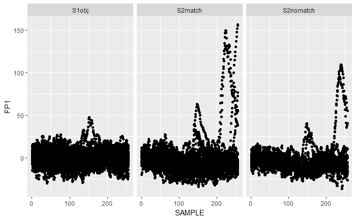

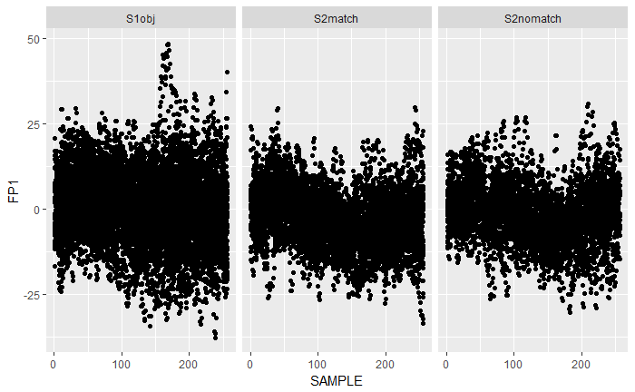

## 4.2. Represent the ‘FP1’ channel as well as the next three

# (non-alcoholic and alcoholic)

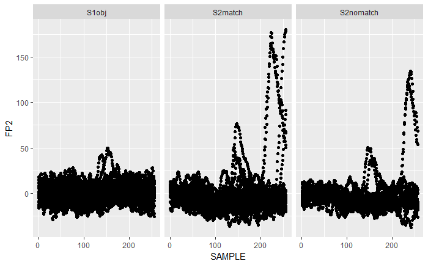

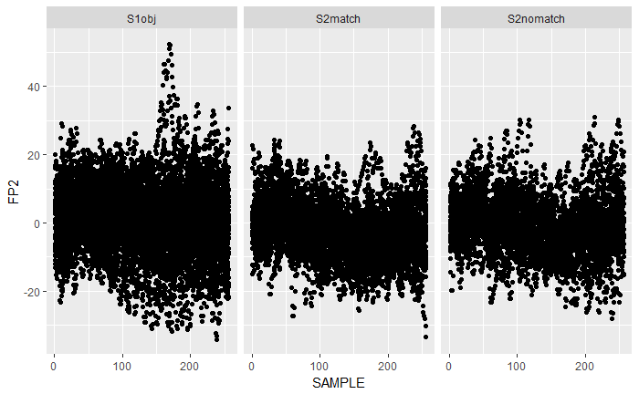

```r
#Control
ggplot(dfCon, aes(x=SAMPLE, y=FP2))+geom_point()+ facet_grid(. ~ EXP_TYPE)
#Alcoholic
ggplot(dfAlc, aes(x=SAMPLE, y=FP2))+geom_point()+ facet_grid(. ~ EXP_TYPE)

mean(dfAlc$FP2)
```

```
[1] -0.3119225
```

```r
mean(dfCon$FP2)
```

```
[1] -1.494225
```

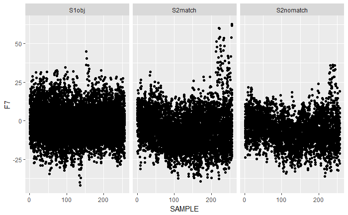

```r
#Control F7
ggplot(dfCon, aes(x=SAMPLE, y=F7))+geom_point() + facet_grid(. ~ EXP_TYPE)
```

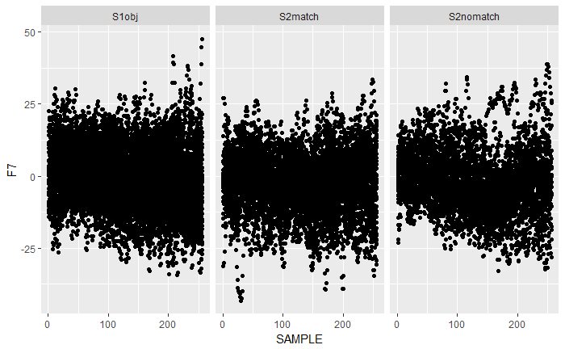

```r
#Alcoholic F7
ggplot(dfAlc, aes(x=SAMPLE, y=F7))+geom_point()+ facet_grid(. ~ EXP_TYPE)
```

```r
mean(dfAlc$F7)
```

```
[1] -1.095995
```

```r
mean(dfCon$F7)
```

```
[1] -3.717741
```

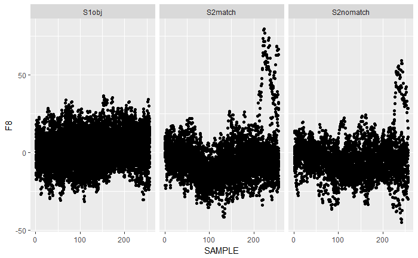

```r
#Control F8
ggplot(dfCon, aes(x=SAMPLE, y=F8))+geom_point() + facet_grid(. ~ EXP_TYPE)
```

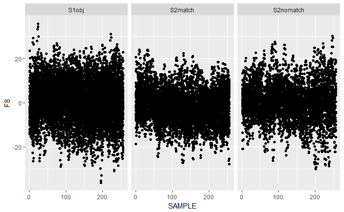

```r
#Alcoholic F8
ggplot(dfAlc, aes(x=SAMPLE, y=F8))+geom_point() + facet_grid(. ~ EXP_TYPE)
```

```r
mean(dfAlc$F8)
```

```
[1] -0.05279417
```

```r
mean(dfCon$F8)
```

```
[1] -1.574346
```

# Step 5 - Data Cleaning

## Is our data in tidy format?

The data we have taken wasn’t in a tidy format, after the transformation that we applied we can assume that yes, it is in a tidy format, we set the variables in columns, we keep the user observations in rows and we have different metadata in different table, one for alcoholic and one for non-alcoholic, we also have a general table with all the data.

Step 5 ##Exercise: Clean the data set

# Exercise: Obtain the quantiles